# Sync-Async Analysis

Removed for Peer Review

6/7/2019

# Loading the data and setting up

This section loads the data and packages and starts to process the data, but doesn’t calculate any statistics or create any results.

## Getting data from Open Science Framework

For notes on this one-time setup, see this walkthrough: http://centerforopenscience.github.io/osfr/articles/auth.html)

First, you must generate an API token from an OSF account that has been added to the data repository. Read how to do this here: https://developer.osf.io/#tag/General-Usage

Then, you need to add the OSF API token to the `.renviron` file, which is created using the following command. Here, the file is created at the user level, although this could also be set to the project level.

```r
usethis::edit_r_environ(scope='user')
```

Open the `.renviron` file and add a single line, using this exact text but replacing `<token>` with your OSF API token:  
`OSF_PAT="<token>"`

Save the file, quit R, and restart in a new session. Continue running the R script from here.

Now, install the `osfr` package and load the library:

```r
devtools::install_github("centerforopenscience/osfr")   # only need to run once
library(osfr)
```

Upon loading the `osfr` package, you should see this message:  
`Automatically registered OSF personal access token.`

Now you are able to retrieve and download the relevant dataset with this code:

```r
osf_retrieve_file("https://osf.io/pxmfc/") %>%
    osf_download(path = "anonymized-dataset.csv", overwrite = TRUE)
```

## Loading the data

Note that we first processed data collected via TAGS (tags.hawksey.info) in order to obtain the tweet IDs, which we then passed to the `lookup_statuses()` rtweet function. We also processed that data to join it with LIWC data and to remove identifying information.

```r
d <- read_csv("anonymized-dataset.csv")
```

## Processing the data

```r
reply_tweets <- d %>%
    mutate(is_reply = !is.na(reply_to_status_id)) %>%
    filter(is_reply) %>%
    count(reply_to_status_id) %>%
    rename(replies_count = n)

length_with_na <- function(x) {
  ifelse(is.na(x), 0, map_int(x, length))
}

proc_tweets <- function(d) {
  d %>%
    mutate(mentions_count = length_with_na(str_split(mentions_screen_name, " ")),
           #hashtags_count = length_with_na(str_split(hashtags, " ")),
           #urls_count = length_with_na(str_split(urls_url, " ")),
           is_reply = if_else(!is.na(reply_to_status_id), TRUE, FALSE))
}

d <- proc_tweets(d)

is.na(d$is_sync) %>% which()  # check to make sure there are no NAs
```

```
## integer(0)
```

```r
prepped_data <- d %>%
    filter(!is_retweet) %>%
    mutate(reply_to_status_id = status_id) %>%
    left_join(reply_tweets, by = "reply_to_status_id") %>%
    mutate(replies_count = ifelse(is.na(replies_count), 0, replies_count)) %>%
    select(screen_name, is_sync,
           social, cogproc, posemo, negemo, work,
           favorite_count, retweet_count, replies_count,
           mentions_count, hashtags_count, urls_count) %>%
    rename(Social = social,
           `Cognitive Processing` = cogproc,
           `Positive Affect` = posemo,
           `Negative Affect` = negemo,
           `Work-related Concerns` = work) %>%
    rename(Likes = favorite_count,
           Retweets = retweet_count,
           Replies = replies_count,
           Mentions = mentions_count) %>%
    rename(Hashtags = hashtags_count,
           URLs = urls_count)
```

# RQ1: Activity

## Plot: Sync vs. Async

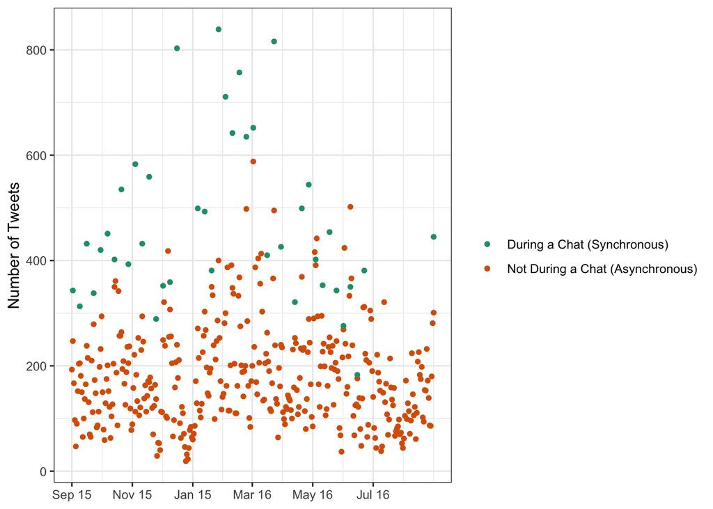

```r
d$created_at_m <- d$created_at - lubridate::hours(5)
d$date_r <- d$created_at_m %>% floor_date("day")

to_plot <- d %>% count(date_r, is_sync) %>% as.data.frame %>%
    tidyr::complete(date_r, is_sync, fill = list(n = 0)) %>%
    filter(date_r != ymd("2015-08-31")) %>%
    mutate(date_r = date_r %>% as_date,
           during_sync_chat = as.factor(is_sync)
    )
levels(to_plot$during_sync_chat) <- c('Not During a Chat (Asynchronous)',
                                      'During a Chat (Synchronous)')

to_plot_sync <- filter(to_plot, is_sync == 1)
to_plot_sync <- mutate(to_plot_sync, n = ifelse(n == 0, NA, n))
to_plot_async <- filter(to_plot, is_sync == 0)

p <- ggplot(to_plot) +
    geom_point(data = to_plot_async, aes(x = date_r, y = n,
                                         group = during_sync_chat,
                                         color = during_sync_chat), size = 1.25) +
    # geom_line(data = to_plot_async, aes(x = date_r, y = n,
    #                                     group = during_sync_chat,
    #                                     color = during_sync_chat), size = .7) +
    geom_point(data = to_plot_sync, aes(x = date_r, y = n,
                                        group = during_sync_chat,
                                        color = during_sync_chat), size = 1.25) +
    scale_color_brewer("", type = "qual", palette = 2) +
    xlab(NULL) +
    ylab("Number of Tweets") +
    scale_x_date(breaks = seq(as.Date("2015-09-01", tz = "America/Detroit"),
                              as.Date("2016-08-31", tz = "America/Detroit"),
                              by = "2 months"),
                 date_labels = "%b %g") +
    theme(axis.text.x = element_text(angle = 45, hjust = 1)) +
    theme(legend.position = "bottom") +
    theme_bw()

p
```

```r
ggsave("sync-async-time-series.png", width = 7, height = 5)
```

## Number of synchronous vs. asynchronous tweets

```r
d %>% nrow()  # total number of tweets
```

```
## [1] 84004
```

```r
#d %>% janitor::tabyl(is_sync)
sync_n <- d %>% janitor::tabyl(is_sync) %>% filter(is_sync==1) %>% pull(n)
async_n <- d %>% janitor::tabyl(is_sync) %>% filter(is_sync==0) %>% pull(n)
sync_n; async_n
```

```
## [1] 18816
```

```
## [1] 65188
```

```r
#(sync_n + async_n) - (d %>% nrow())  # make sure all rows are accounted for
## test if difference is significant
chisq.test(c(sync_n, async_n))
```

```
##
##  Chi-squared test for given probabilities
##
## data:  c(sync_n, async_n)
## X-squared = 25598, df = 1, p-value < 2.2e-16
```

```r
d
```

```
## # A tibble: 84,004 x 115
##    status_id created_at          screen_name reply_to_status… is_quote
##    <chr>     <dttm>              <chr>       <chr>            <lgl>
##  1 status_1  2015-09-01 09:40:17 username_1  <NA>             FALSE
##  2 status_2  2015-08-31 14:06:37 username_1  <NA>             FALSE
##  3 status_3  2016-01-28 01:47:05 username_1  status_20999     FALSE
##  4 status_4  2016-02-11 00:28:33 username_1  <NA>             TRUE
##  5 status_5  2015-11-24 17:32:13 username_1  <NA>             FALSE
##  6 status_6  2016-05-26 00:39:10 username_1  <NA>             FALSE
##  7 status_7  2015-12-08 12:47:53 username_1  <NA>             FALSE
##  8 status_8  2016-03-01 15:27:29 username_1  <NA>             FALSE
##  9 status_9  2016-05-05 00:20:22 username_1  <NA>             FALSE
## 10 status_10 2015-09-01 13:16:01 username_1  <NA>             FALSE
## # … with 83,994 more rows, and 110 more variables: is_retweet <lgl>,
## #   favorite_count <dbl>, retweet_count <dbl>, hashtags <chr>, symbols <lgl>,
## #   urls_url <chr>, urls_t.co <chr>, urls_expanded_url <chr>,
## #   mentions_screen_name <chr>, is_sync <dbl>, type <chr>, WC <dbl>,
## #   Analytic <dbl>, Clout <dbl>, Authentic <dbl>, Tone <dbl>, WPS <dbl>,
## #   Sixltr <dbl>, Dic <dbl>, `function` <dbl>, pronoun <dbl>, ppron <dbl>,
## #   i <dbl>, we <dbl>, you <dbl>, shehe <dbl>, they <dbl>, ipron <dbl>,
## #   article <dbl>, prep <dbl>, auxverb <dbl>, adverb <dbl>, conj <dbl>,
## #   negate <dbl>, verb <dbl>, adj <dbl>, compare <dbl>, interrog <dbl>,
## #   number <dbl>, quant <dbl>, affect <dbl>, posemo <dbl>, negemo <dbl>,
## #   anx <dbl>, anger <dbl>, sad <dbl>, social <dbl>, family <dbl>,
## #   friend <dbl>, female <dbl>, male <dbl>, cogproc <dbl>, insight <dbl>,
## #   cause <dbl>, discrep <dbl>, tentat <dbl>, certain <dbl>, differ <dbl>,
## #   percept <dbl>, see <dbl>, hear <dbl>, feel <dbl>, bio <dbl>, body <dbl>,
## #   health <dbl>, sexual <dbl>, ingest <dbl>, drives <dbl>, affiliation <dbl>,
## #   achieve <dbl>, power <dbl>, reward <dbl>, risk <dbl>, focuspast <dbl>,
## #   focuspresent <dbl>, focusfuture <dbl>, relativ <dbl>, motion <dbl>,
## #   space <dbl>, time <dbl>, work <dbl>, leisure <dbl>, home <dbl>,
## #   money <dbl>, relig <dbl>, death <dbl>, informal <dbl>, swear <dbl>,
## #   netspeak <dbl>, assent <dbl>, nonflu <dbl>, filler <dbl>, AllPunc <dbl>,
## #   Period <dbl>, Comma <dbl>, Colon <dbl>, SemiC <dbl>, QMark <dbl>,
## #   Exclam <dbl>, Dash <dbl>, …
```

```r
library(lme4)
```

```r
sjPlot::tab_model(glm(is_sync ~ 1, data = d, family = "poisson"), show.se = TRUE)
```

|  | is sync |  |  |  |
| --- | --- | --- | --- | --- |
| Predictors | Incidence Rate Ratios | std. Error | CI | p |
| (Intercept) | 0.22 | 0.01 | 0.22 – 0.23 | **<0.001** |
| Observations | 84004 |  |  |  |
| R<sup>2</sup> Nagelkerke | 0.000 |  |  |  |

```r
glmer(is_sync ~ 1 + (1|screen_name), data = d, family = "poisson")
```

```
## Generalized linear mixed model fit by maximum likelihood (Laplace
##   Approximation) [glmerMod]
##  Family: poisson  ( log )
## Formula: is_sync ~ 1 + (1 | screen_name)
##    Data: d
##       AIC       BIC    logLik  deviance  df.resid
##  71304.84  71323.51 -35650.42  71300.84     84002
## Random effects:
##  Groups      Name        Std.Dev.
##  screen_name (Intercept) 2.344
## Number of obs: 84004, groups:  screen_name, 9462
## Fixed Effects:
## (Intercept)
##      -4.111
```

```r
d_quote <- d %>% filter(is_quote)
d_quote
```

```
## # A tibble: 4,149 x 115
##    status_id created_at          screen_name reply_to_status… is_quote
##    <chr>     <dttm>              <chr>       <chr>            <lgl>
##  1 status_4  2016-02-11 00:28:33 username_1  <NA>             TRUE
##  2 status_79 2015-09-01 13:32:39 username_1  <NA>             TRUE
##  3 status_4… 2015-11-26 01:42:48 username_1  <NA>             TRUE
##  4 status_1… 2015-09-15 01:48:15 username_1  <NA>             TRUE
##  5 status_1… 2015-10-21 02:24:46 username_1  <NA>             TRUE
##  6 status_1… 2015-12-17 01:28:27 username_1  <NA>             TRUE
##  7 status_1… 2015-10-22 00:12:47 username_1  <NA>             TRUE
##  8 status_1… 2015-10-22 00:21:46 username_1  <NA>             TRUE
##  9 status_1… 2016-04-26 13:28:21 username_1  <NA>             TRUE
## 10 status_1… 2016-04-26 13:27:04 username_1  <NA>             TRUE
## # … with 4,139 more rows, and 110 more variables: is_retweet <lgl>,
## #   favorite_count <dbl>, retweet_count <dbl>, hashtags <chr>, symbols <lgl>,
## #   urls_url <chr>, urls_t.co <chr>, urls_expanded_url <chr>,
## #   mentions_screen_name <chr>, is_sync <dbl>, type <chr>, WC <dbl>,
## #   Analytic <dbl>, Clout <dbl>, Authentic <dbl>, Tone <dbl>, WPS <dbl>,
## #   Sixltr <dbl>, Dic <dbl>, `function` <dbl>, pronoun <dbl>, ppron <dbl>,
## #   i <dbl>, we <dbl>, you <dbl>, shehe <dbl>, they <dbl>, ipron <dbl>,
## #   article <dbl>, prep <dbl>, auxverb <dbl>, adverb <dbl>, conj <dbl>,
## #   negate <dbl>, verb <dbl>, adj <dbl>, compare <dbl>, interrog <dbl>,
## #   number <dbl>, quant <dbl>, affect <dbl>, posemo <dbl>, negemo <dbl>,
## #   anx <dbl>, anger <dbl>, sad <dbl>, social <dbl>, family <dbl>,
## #   friend <dbl>, female <dbl>, male <dbl>, cogproc <dbl>, insight <dbl>,
## #   cause <dbl>, discrep <dbl>, tentat <dbl>, certain <dbl>, differ <dbl>,
## #   percept <dbl>, see <dbl>, hear <dbl>, feel <dbl>, bio <dbl>, body <dbl>,
## #   health <dbl>, sexual <dbl>, ingest <dbl>, drives <dbl>, affiliation <dbl>,
## #   achieve <dbl>, power <dbl>, reward <dbl>, risk <dbl>, focuspast <dbl>,
## #   focuspresent <dbl>, focusfuture <dbl>, relativ <dbl>, motion <dbl>,
## #   space <dbl>, time <dbl>, work <dbl>, leisure <dbl>, home <dbl>,
## #   money <dbl>, relig <dbl>, death <dbl>, informal <dbl>, swear <dbl>,
## #   netspeak <dbl>, assent <dbl>, nonflu <dbl>, filler <dbl>, AllPunc <dbl>,
## #   Period <dbl>, Comma <dbl>, Colon <dbl>, SemiC <dbl>, QMark <dbl>,
## #   Exclam <dbl>, Dash <dbl>, …
```

```r
glm(is_sync ~ 1, data = d_quote, family = "poisson")
```

```
##
## Call:  glm(formula = is_sync ~ 1, family = "poisson", data = d_quote)
##
## Coefficients:
## (Intercept)
##      -1.402
##
## Degrees of Freedom: 4148 Total (i.e. Null);  4148 Residual
## Null Deviance:       2863
## Residual Deviance: 2863  AIC: 4907
```

```r
glmer(is_sync ~ 1 + (1|screen_name), data = d_quote, family = "poisson")
```

```
## Generalized linear mixed model fit by maximum likelihood (Laplace
##   Approximation) [glmerMod]
##  Family: poisson  ( log )
## Formula: is_sync ~ 1 + (1 | screen_name)
##    Data: d_quote
##       AIC       BIC    logLik  deviance  df.resid
##  3975.911  3988.573 -1985.956  3971.911      4147
## Random effects:
##  Groups      Name        Std.Dev.
##  screen_name (Intercept) 1.323
## Number of obs: 4149, groups:  screen_name, 516
## Fixed Effects:
## (Intercept)
##       -2.18
```

## Number of synchronous vs. asynchronous / original vs. nonoriginal tweeters

```r
## Number of distinct tweeters
d %>% pull(screen_name) %>% tolower() %>% unique() %>% length()
```

```
## [1] 9462
```

```r
tweeters_df <- d %>%
    mutate(screen_name = screen_name %>% tolower) %>%
    group_by(is_sync) %>%
    summarize(unique_tweeters = (screen_name %>% unique %>% length))
sync_tweeters_n <- tweeters_df %>% filter(is_sync==1) %>% pull(unique_tweeters)
async_tweeters_n <- tweeters_df %>% filter(is_sync==0) %>% pull(unique_tweeters)
sync_tweeters_n; async_tweeters_n
```

```
## [1] 1325
```

```
## [1] 8974
```

```r
both <- d %>% count(screen_name, is_sync) %>%
    count(screen_name) %>% filter(n == 2)
both_n <- both %>% nrow()
only_one <- d %>% count(screen_name, is_sync) %>%
    count(screen_name) %>% filter(n == 1)
sync_only_n <- d %>% semi_join(only_one, by="screen_name") %>%
    mutate(screen_name = screen_name %>% tolower) %>%
    filter(is_sync==1) %>%
    count(screen_name, is_sync) %>%
    count(screen_name) %>% filter(n == 1) %>%
    nrow()
async_only_n <- d %>% semi_join(only_one, by="screen_name") %>%
    mutate(screen_name = screen_name %>% tolower) %>%
    filter(is_sync==0) %>%
    count(screen_name, is_sync) %>%
    count(screen_name) %>% filter(n == 1) %>%
    nrow()
paste("Both:", both_n); paste("Sync Only:", sync_only_n); paste("Async Only:", async_only_n)
```

```
## [1] "Both: 837"
```

```
## [1] "Sync Only: 488"
```

```
## [1] "Async Only: 8137"
```

```r
only_one_original <- d %>% count(screen_name, is_retweet) %>%
    count(screen_name) %>% filter(n == 1)
both_original <- d %>% count(screen_name, is_retweet) %>%
    count(screen_name) %>% filter(n == 2)
both_original_n <- both_original %>% nrow()
sync_only_original <- d %>%
    semi_join(only_one, by="screen_name") %>%
    semi_join(only_one_original, by ="screen_name") %>%
    mutate(screen_name = screen_name %>% tolower) %>%
    filter(is_sync==1 & !is_retweet) %>%
    count(screen_name, is_sync) %>%
    count(screen_name) %>% filter(n == 1) %>%
    nrow()
sync_only_nonoriginal <- d %>% semi_join(only_one, by="screen_name") %>%
    semi_join(only_one_original, by ="screen_name") %>%
    mutate(screen_name = screen_name %>% tolower) %>%
    filter(is_sync==1 & is_retweet) %>%
    count(screen_name, is_sync) %>%
    count(screen_name) %>% filter(n == 1) %>%
    nrow()
sync_only_both <- d %>% semi_join(both_original, by="screen_name") %>%
    semi_join(only_one, by ="screen_name") %>%
    mutate(screen_name = screen_name %>% tolower) %>%
    filter(is_sync==1) %>%
    count(screen_name, is_sync) %>%
    count(screen_name) %>% filter(n == 1) %>%
    nrow()
paste("Total Sync:", sync_only_n); paste("Sync, Original Only", sync_only_original); paste("Sync, Nonoriginal Only", sync_only_nonoriginal); paste("Sync, Original and Nonoriginal", sync_only_both); paste("Total Check:", sync_only_original + sync_only_nonoriginal + sync_only_both)
```

```
## [1] "Total Sync: 488"
```

```
## [1] "Sync, Original Only 174"
```

```
## [1] "Sync, Nonoriginal Only 278"
```

```
## [1] "Sync, Original and Nonoriginal 36"
```

```
## [1] "Total Check: 488"
```

```r
async_only_original <- d %>%
    semi_join(only_one, by="screen_name") %>%
    semi_join(only_one_original, by ="screen_name") %>%
    mutate(screen_name = screen_name %>% tolower) %>%
    filter(is_sync==0 & !is_retweet) %>%
    count(screen_name, is_sync) %>%
    count(screen_name) %>% filter(n == 1) %>%
    nrow()
async_only_nonoriginal <- d %>% semi_join(only_one, by="screen_name") %>%
    semi_join(only_one_original, by ="screen_name") %>%
    mutate(screen_name = screen_name %>% tolower) %>%
    filter(is_sync==0 & is_retweet) %>%
    count(screen_name, is_sync) %>%
    count(screen_name) %>% filter(n == 1) %>%
    nrow()
async_only_both <- d %>% semi_join(both_original, by="screen_name") %>%
    semi_join(only_one, by ="screen_name") %>%
    mutate(screen_name = screen_name %>% tolower) %>%
    filter(is_sync==0) %>%
    count(screen_name, is_sync) %>%
    count(screen_name) %>% filter(n == 1) %>%
    nrow()
paste("Total Async:", async_only_n); paste("Async, Original Only", async_only_original); paste("Async, Nonoriginal Only", async_only_nonoriginal); paste("Async, Original and Nonoriginal", async_only_both); paste("Total Check:", async_only_original + async_only_nonoriginal + async_only_both)
```

```
## [1] "Total Async: 8137"
```

```
## [1] "Async, Original Only 519"
```

```
## [1] "Async, Nonoriginal Only 7151"
```

```
## [1] "Async, Original and Nonoriginal 467"
```

```
## [1] "Total Check: 8137"
```

```r
both_original_ <- d %>%
    semi_join(both, by="screen_name") %>%
    semi_join(only_one_original, by ="screen_name") %>%
    mutate(screen_name = screen_name %>% tolower) %>%
    filter(!is_retweet) %>%
    count(screen_name, is_retweet) %>%
    count(screen_name) %>%
    nrow()
both_nonoriginal <- d %>% semi_join(both, by="screen_name") %>%
    semi_join(both, by="screen_name") %>%
    semi_join(only_one_original, by ="screen_name") %>%
    mutate(screen_name = screen_name %>% tolower) %>%
    filter(is_retweet) %>%
    count(screen_name, is_retweet) %>%
    count(screen_name) %>%
    nrow()
both_both <- d %>% semi_join(both_original, by="screen_name") %>%
    semi_join(both, by="screen_name") %>%
    mutate(screen_name = screen_name %>% tolower) %>%
    count(screen_name, is_retweet) %>%
    count(screen_name) %>%
    nrow()
paste("Total Both:", both_n); paste("Both, Original Only", both_original_); paste("Both, Nonoriginal Only", both_nonoriginal); paste("Both, Original and Nonoriginal", both_both); paste("Total Check:", both_original_ + both_nonoriginal + both_both)
```

```
## [1] "Total Both: 837"
```

```
## [1] "Both, Original Only 90"
```

```
## [1] "Both, Nonoriginal Only 224"
```

```
## [1] "Both, Original and Nonoriginal 523"
```

```
## [1] "Total Check: 837"
```

```r
chisq.test(rbind(c(sync_only_original, async_only_original, both_original_),
                 c(sync_only_nonoriginal, async_only_nonoriginal, both_nonoriginal),
                 c(sync_only_both, async_only_both, both_both)))
```

```
##
##  Pearson's Chi-squared test
##
## data:  rbind(c(sync_only_original, async_only_original, both_original_),     c(sync_only_nonoriginal, async_only_nonoriginal, both_nonoriginal),     c(sync_only_both, async_only_both, both_both))
## X-squared = 3130.1, df = 4, p-value < 2.2e-16
```

```r
chisq.test(rbind(c(sync_only_original, async_only_original, both_original_),
                 c(sync_only_nonoriginal, async_only_nonoriginal, both_nonoriginal),
                 c(sync_only_both, async_only_both, both_both)))
```

```
##
##  Pearson's Chi-squared test
##
## data:  rbind(c(sync_only_original, async_only_original, both_original_),     c(sync_only_nonoriginal, async_only_nonoriginal, both_nonoriginal),     c(sync_only_both, async_only_both, both_both))
## X-squared = 3130.1, df = 4, p-value < 2.2e-16
```

```r
rbind(c(sync_only_original, async_only_original, both_original_),
                 c(sync_only_nonoriginal, async_only_nonoriginal, both_nonoriginal),
                 c(sync_only_both, async_only_both, both_both))
```

```
##      [,1] [,2] [,3]
## [1,]  174  519   90
## [2,]  278 7151  224
## [3,]   36  467  523
```

# RQs 2-4: Content, Interactions, Portals

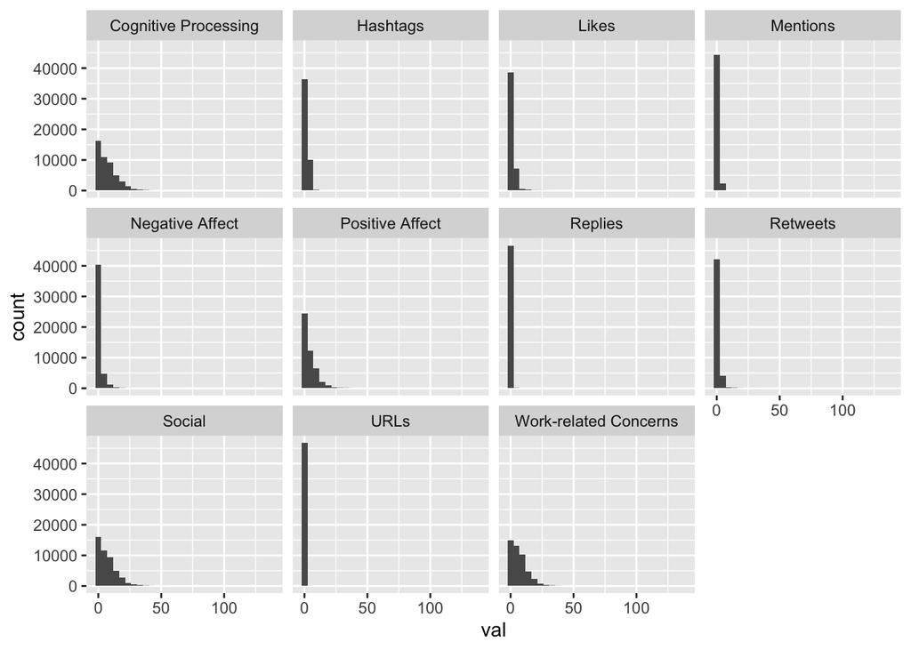

```r
prepped_data %>%
    select(-is_sync, -screen_name) %>%
    gather(key, val) %>%
    ggplot(aes(x = val)) +
    geom_histogram() +
    facet_wrap(~key)
```

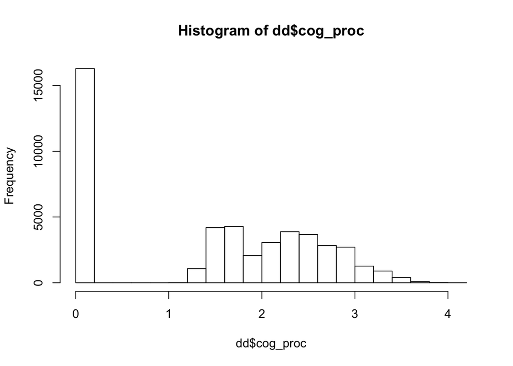

```r
safe_log <- function(x) {
    ifelse(x == 0, 0, log(x))
}

dd <- prepped_data %>%
    mutate(cog_proc = safe_log(`Cognitive Processing`))
hist(dd$cog_proc)
```

```r
psych::describe(dd$cog_proc)
```

```
##    vars     n mean   sd median trimmed  mad min  max range  skew kurtosis   se
## X1    1 46726 1.44 1.15   1.66    1.41 1.48   0 4.09  4.09 -0.16    -1.44 0.01
```

```r
library(lme4)
m1 <- lm(`Cognitive Processing` ~ is_sync, data = prepped_data)
summary(m1)
```

```
##
## Call:
## lm(formula = `Cognitive Processing` ~ is_sync, data = prepped_data)
##
## Residuals:
##     Min      1Q  Median      3Q     Max
## -10.375  -5.597  -0.855   3.915  49.625
##
## Coefficients:
##             Estimate Std. Error t value Pr(>|t|)
## (Intercept)  5.59725    0.03867  144.74   <2e-16 ***
## is_sync      4.77819    0.07124   67.08   <2e-16 ***
## ---
## Signif. codes:  0 '***' 0.001 '**' 0.01 '*' 0.05 '.' 0.1 ' ' 1
##
## Residual standard error: 7.02 on 46724 degrees of freedom
## Multiple R-squared:  0.08783,    Adjusted R-squared:  0.08781
## F-statistic:  4499 on 1 and 46724 DF,  p-value: < 2.2e-16
```

```r
m1lmer <- lmer(`Cognitive Processing` ~ is_sync + (1|screen_name), data = prepped_data)
summary(m1lmer)
```

```
## Linear mixed model fit by REML ['lmerMod']
## Formula: `Cognitive Processing` ~ is_sync + (1 | screen_name)
##    Data: prepped_data
##
## REML criterion at convergence: 313448.1
##
## Scaled residuals:
##     Min      1Q  Median      3Q     Max
## -2.1776 -0.7257 -0.1362  0.5520  7.1723
##
## Random effects:
##  Groups      Name        Variance Std.Dev.
##  screen_name (Intercept)  4.437   2.106
##  Residual                46.870   6.846
## Number of obs: 46726, groups:  screen_name, 1809
##
## Fixed effects:
##             Estimate Std. Error t value
## (Intercept)  5.90876    0.09129   64.72
## is_sync      4.31869    0.08748   49.37
##
## Correlation of Fixed Effects:
##         (Intr)
## is_sync -0.343
```

```r
sjstats::icc(m1lmer)
```

```
## # Intraclass Correlation Coefficient
##
##      Adjusted ICC: 0.086
##   Conditional ICC: 0.080
```

```r
m2lmer <- glmer(Replies ~ is_sync + (1|screen_name), family = "poisson", data = prepped_data)
summary(m2lmer)
```

```
## Generalized linear mixed model fit by maximum likelihood (Laplace
##   Approximation) [glmerMod]
##  Family: poisson  ( log )
## Formula: Replies ~ is_sync + (1 | screen_name)
##    Data: prepped_data
##
##      AIC      BIC   logLik deviance df.resid
##  26809.8  26836.1 -13401.9  26803.8    46723
##
## Scaled residuals:
##     Min      1Q  Median      3Q     Max
## -1.6628 -0.3934 -0.1438 -0.1148 19.5484
##
## Random effects:
##  Groups      Name        Variance Std.Dev.
##  screen_name (Intercept) 0.3043   0.5516
## Number of obs: 46726, groups:  screen_name, 1809
##
## Fixed effects:
##             Estimate Std. Error z value Pr(>|z|)
## (Intercept) -4.00973    0.05051  -79.39   <2e-16 ***
## is_sync      2.32871    0.04724   49.30   <2e-16 ***
## ---
## Signif. codes:  0 '***' 0.001 '**' 0.01 '*' 0.05 '.' 0.1 ' ' 1
##
## Correlation of Fixed Effects:
##         (Intr)
## is_sync -0.702
```

```r
exp(2.32)
```

```
## [1] 10.17567
```

```r
sjstats::icc(m2lmer)
```

```
## # Intraclass Correlation Coefficient
##
##      Adjusted ICC: 0.090
##   Conditional ICC: 0.067
```

This creates a table for the subsequent analyses.

```r
mean_stats <- prepped_data %>%
    select(-screen_name) %>%
    group_by(is_sync) %>%
    summarize_all(funs(mean, sd, n())) %>%
    gather(key, val, -is_sync) %>%
    separate(key, c("var", "stat"), sep = "\\_") %>%
    spread(stat, val) %>%
    mutate(se = sd / sqrt(n - 1)) %>%
    mutate(is_sync = factor(is_sync, labels = c("Asynchronous", "Synchronous"))) %>%
    mutate(mean_se = str_c(round(mean, 3), " (", round(se, 3), ")")) %>%
    select(is_sync, var, mean_se) %>%
    spread(is_sync, mean_se) %>%
    mutate(group = c(
        "content",
        "portals",
        "interactions",
        "interactions",
        "content",
        "content",
        "interactions",
        "interactions",
        "content",
        "portals",
        "content"
    )) %>%
    arrange(group, var)
```

Note - we replace these with multi-level LMs and GLMS, as below.

```r
library(lme4)

m1 <- lmer(Social ~ is_sync + (1|screen_name), data = prepped_data)
m2 <- lmer(`Cognitive Processing` ~ is_sync + (1|screen_name), data = prepped_data)
m3 <- lmer(`Positive Affect` ~ is_sync + (1|screen_name), data = prepped_data)
m4 <- lmer(`Negative Affect` ~ is_sync + (1|screen_name), data = prepped_data)
m5 <- lmer(`Work-related Concerns` ~ is_sync + (1|screen_name), data = prepped_data)

m7 <- glmer(Retweets ~ is_sync + (1|screen_name), family = "poisson", data = prepped_data,
            control = glmerControl(optimizer = "nloptwrap"))
m8 <- glmer(Replies ~ is_sync + (1|screen_name), family = "poisson", data = prepped_data)

# warning for m9
# m90 <- glmer(Mentions ~ 1 + (1|screen_name), family = "poisson", data = prepped_data)
# performance:icc(m90)
m9 <- glmer(Mentions ~ is_sync + (1|screen_name), family = "poisson", data = prepped_data,
            control = glmerControl(
                           optimizer = "nloptwrap"))
m10 <- glmer(Hashtags ~ is_sync + (1|screen_name), family = "poisson", data = prepped_data)
m11 <- glmer(URLs ~ is_sync + (1|screen_name), family = "poisson", data = prepped_data)
m12 <- glmer(Likes ~ is_sync + (1|screen_name), family = "poisson", data = prepped_data)
```

```r
diagnostics_func <- function(m, prepped_data) {
  l1 <- plot(resid(m, data = prepped_data))
  l2 <- car::leveneTest(residuals(m) ~ as.factor(prepped_data$is_sync))
  l3 <- lattice::qqmath(m, id = .05)
  list(l1, l2, l3)
}
```

```r
get_stats <- function(m) {
  x <- broom::tidy(m)
  o <- filter(x, group == "fixed")
  o <- mutate(o, est_se = str_c(round(estimate, 3), " (", round(std.error, 3), ")"))
  o <- as.vector(unlist(select(o, est_se)))
  i <- round(as.vector(performance::icc(m))[[1]][1], 3)

  d <- data.frame(int_est_se = o[1], sync_est_se = o[2], icc = i)
  return(d)
}

ol <- list(m2, m3, m1, m5, m4,
          m8, m7, m9, m12,
          m10, m11)

l <- ol %>%
  map_df(get_stats)
```

[output not shown]

```r
# l %>% clipr::write_clip()

EMAtools::lme.dscore(m4, data = prepped_data, type = "lme4")
```

```
##                t       df         d
## is_sync 10.32772 19405.23 0.1482774
```

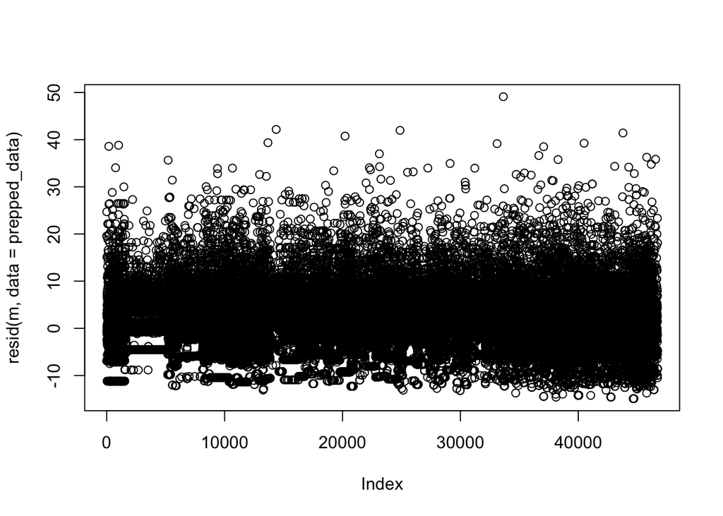

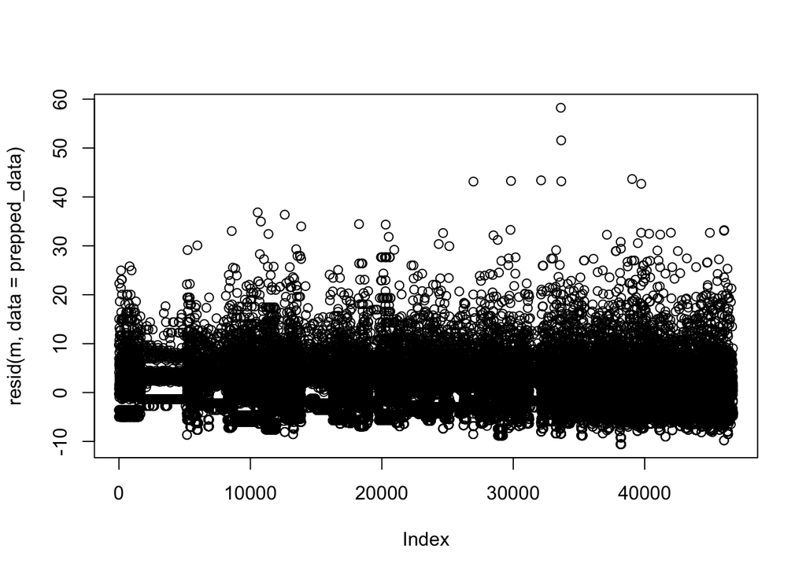

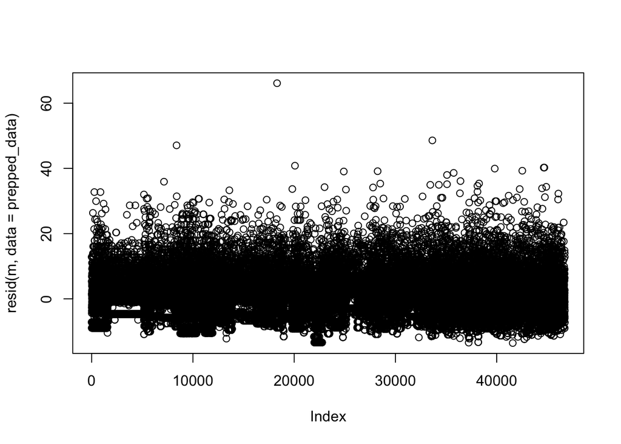

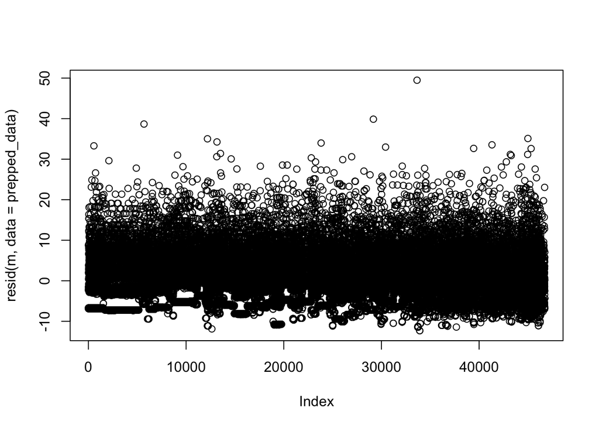

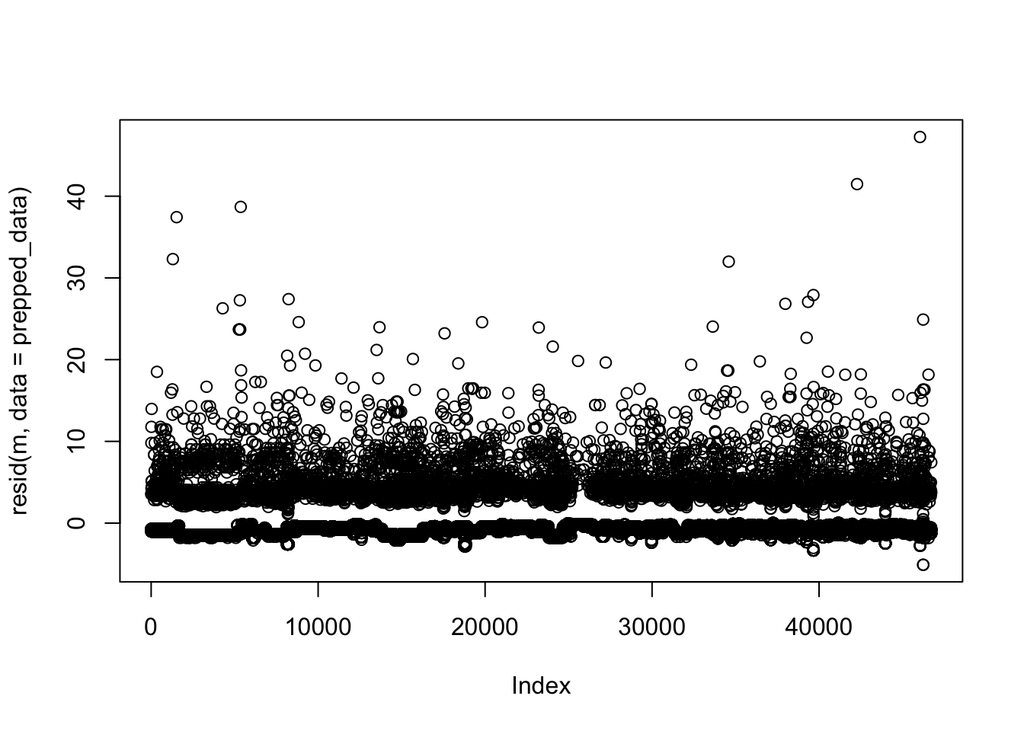

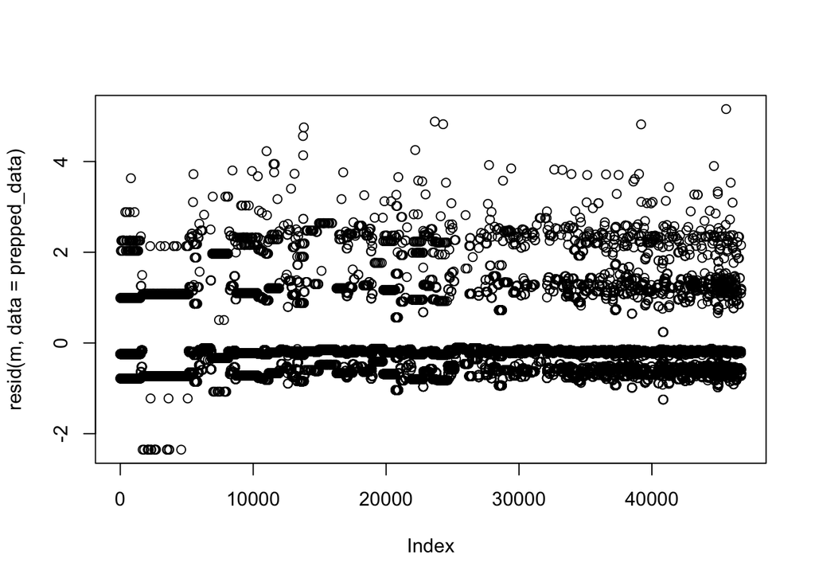

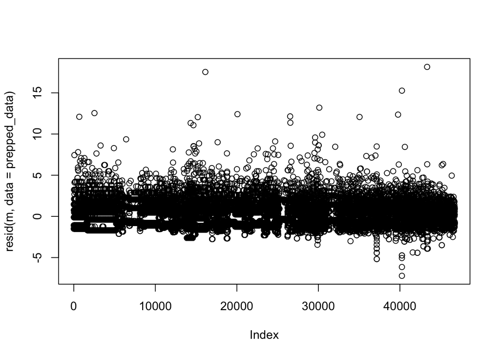

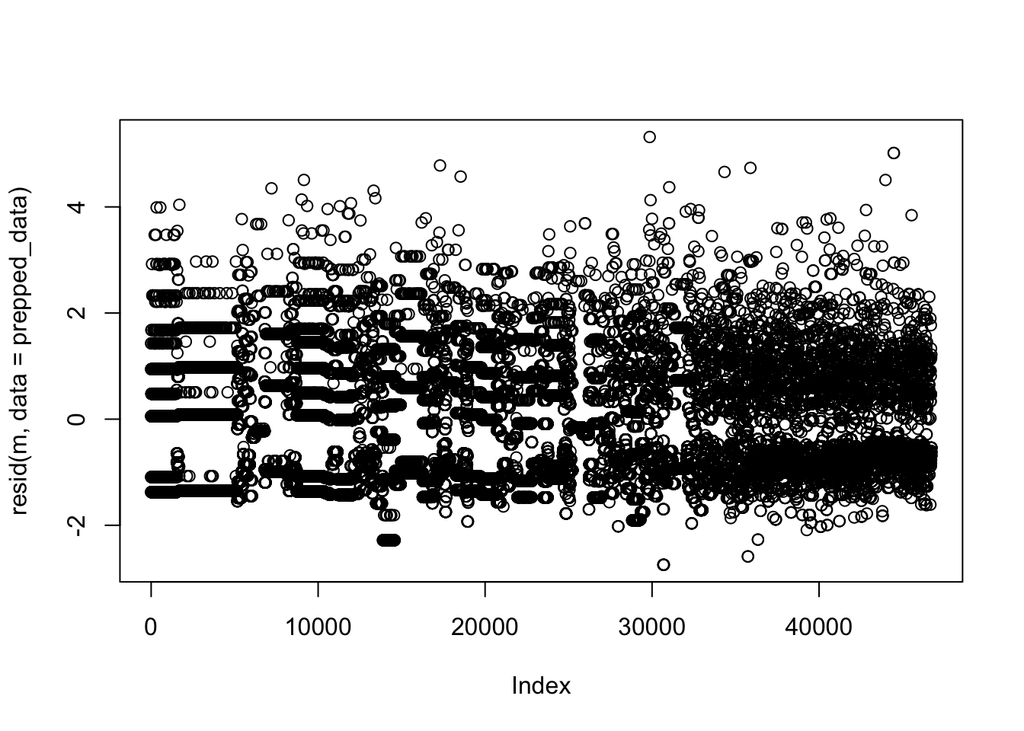

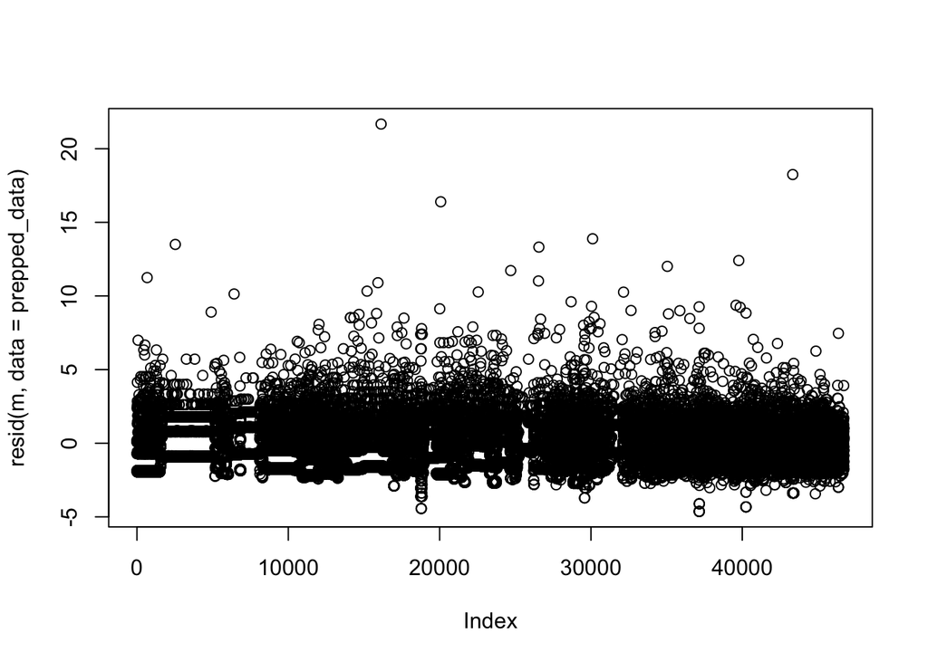

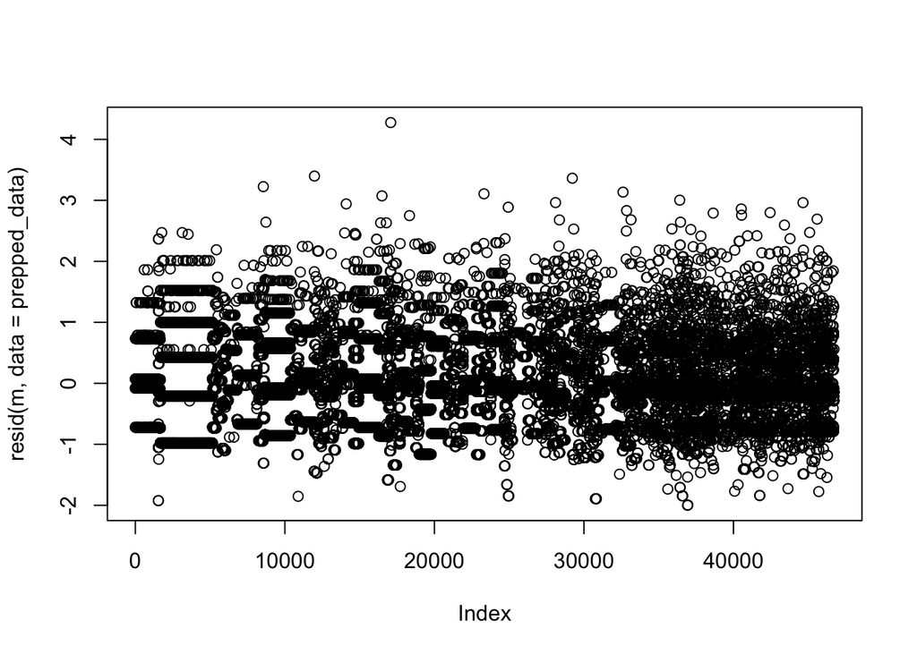

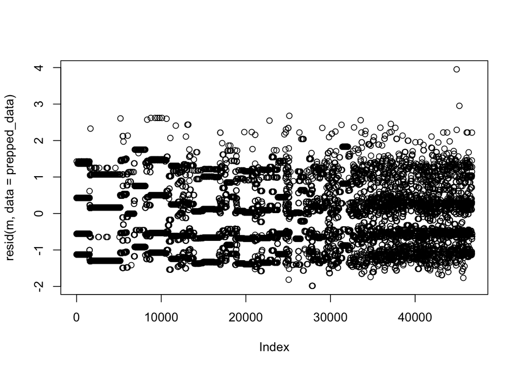

```r
ll <- ol %>%
  map(diagnostics_func, prepped_data = prepped_data)
```

## Number of synchronous vs. asynchronous quote tweets

```r
d %>% filter(is_quote==TRUE) %>% nrow()  # total number of quote tweets
```

```
## [1] 4149
```

```r
sync_quote_n <- d %>% filter(is_quote==TRUE) %>%
    janitor::tabyl(is_sync) %>% filter(is_sync==1) %>% pull(n)
async_quote_n <- d %>% filter(is_quote==TRUE) %>%
    janitor::tabyl(is_sync) %>% filter(is_sync==0) %>% pull(n)
sync_quote_n; async_quote_n
```

```
## [1] 1021
```

```
## [1] 3128
```

```r
## test if difference is significant
chisq.test(c(sync_quote_n, async_quote_n))
```

```
##
##  Chi-squared test for given probabilities
##
## data:  c(sync_quote_n, async_quote_n)
## X-squared = 1070, df = 1, p-value < 2.2e-16
```

## creates categorical variables for sync/async; original/retweet

```r
# Variable 1, a categorical with: only sync, only async, both async and sync

sync_names <- d %>% filter(is_sync == TRUE) %>% pull(screen_name) %>% unique()
async_names <- d %>% filter(is_sync == FALSE) %>% pull(screen_name) %>% unique()

both_names <- sync_names[sync_names %in% async_names]

only_sync <- sync_names[!sync_names %in% both_names]
only_async <- async_names[!async_names %in% both_names]

d <- d %>% mutate(sync_categorical = ifelse(screen_name %in% both_names, "both", ifelse(screen_name %in% only_sync, "sync", "async")))

# Variable 2, a categorical with: only original, only retweeting, and original and retweeting

original_names <- d %>% filter(is_retweet == FALSE) %>% pull(screen_name) %>% unique()
retweet_names <- d %>% filter(is_retweet == TRUE) %>% pull(screen_name) %>% unique()

both_o_names <- original_names[original_names %in% retweet_names]

only_retweet <- retweet_names[!retweet_names %in% both_o_names]
only_original <- original_names[!original_names %in% both_o_names]

both_o_names %>% length()
```

```
## [1] 1026
```

```r
d <- d %>% mutate(original_categorical = ifelse(screen_name %in% both_o_names, "both", ifelse(screen_name %in% only_original, "original", "retweet")))

d %>% filter(original_categorical == "retweet") %>% pull(screen_name)%>% unique() %>% length()
```

```
## [1] 7653
```

# R version and package info